# **PCFL 2022: Week 9 wrap-up**

Hey all! We’ve got just six weeks to go in the regular season. Fantasy life moves fast.

## Last week’s games

[output not shown]

I’ve already whined on GroupMe about my narrow loss to Erin & Trav in part due to Kenyan Drake, who was on wavers just 48 hours before beating me. Sigh.

Sarah had a second huge week points wise, this time powered by Joe Mixon, and got Jacob’s GOAT. Jacob, by the way, had THREE starters who were on bye and still got nearly 100 points.

Other winners last week were Scott, Brian, and Evan.

## Best performances

### Best players overall

Here’s last week’s **10 best performing starters.**

| Player | Position | NFL Team | Points | PCFL Team |
| --- | --- | --- | --- | --- |
| Joe Mixon | RB | CIN | 53.10 | Southern Sharks |
| Patrick Mahomes | QB | KCC | 34.14 | Southern Sharks |
| Davante Adams | WR | OAK | 31.60 | The G.O.A.T. |
| Kenneth Walker III | RB | SEA | 26.40 | Georgia Peanuts |
| Travis Etienne Jr. | RB | JAC | 25.60 | The G.O.A.T. |
| Josh Allen | QB | BUF | 24.80 | Athens Team Sasquatch |
| Kenyan Drake | RB | BAL | 23.90 | The Juniors |
| Tyreek Hill | WR | MIA | 23.80 | The Juniors |
| Cooper Kupp | WR | LAR | 23.80 | The G.O.A.T. |
| Derrick Henry | RB | TEN | 23.50 | Southern Sharks |

Already mentioned Joe Mixon. Disappointing last week, but a very nice performance this week. A couple of break out running backs (Walker and Etienne) as well as Kenyan Drake’s two touchdown day.

### Best players per team

Here’s last week’s top players **on each team.**

| Player | Position | NFL Team | Points | PCFL Team |
| --- | --- | --- | --- | --- |
| Josh Allen | QB | BUF | 24.80 | Athens Team Sasquatch |
| Joe Burrow | QB | CIN | 19.14 | Captain Clairvoyant |
| Justin Fields | BE | CHI | 42.72 | Georgia Peanuts |
| Austin Ekeler | RB | LAC | 20.60 | Jumpin’ Jaheims |
| Nick Folk | K | NEP | 17.00 | KC Gophers |
| Patriots D/ST | BE | NEP | 26.00 | Middle Earth Hangry Hobbits |
| Curtis Samuel | WR | WAS | 16.60 | Pigskin on the Gridiron |
| Joe Mixon | RB | CIN | 53.10 | Southern Sharks |
| Davante Adams | WR | OAK | 31.60 | The G.O.A.T. |
| Kenyan Drake | RB | BAL | 23.90 | The Juniors |

Crissy’s top scorer this week was a kicker. And for the Hobbits it was the New England Defense. Not sure what that all means.

### Best bench

Who won the **best scoring bench** award last week?

| Team | Bench points |
| --- | --- |
| Middle Earth Hangry Hobbits | 71.48 |
| The G.O.A.T. | 70.70 |
| Jumpin’ Jaheims | 68.45 |
| Athens Team Sasquatch | 66.64 |
| Georgia Peanuts | 46.32 |
| The Juniors | 23.45 |
| Southern Sharks | 18.60 |
| Captain Clairvoyant | 12.58 |
| Pigskin on the Gridiron | 10.70 |
| KC Gophers | 8.20 |

Scott edged out Jacob this week.

Here’s the season’s bench standings:

| Team | Bench points |
| --- | --- |
| Middle Earth Hangry Hobbits | 584.71 |
| The G.O.A.T. | 579.80 |
| Jumpin’ Jaheims | 556.28 |
| KC Gophers | 534.25 |
| Southern Sharks | 439.74 |
| Georgia Peanuts | 411.92 |
| Pigskin on the Gridiron | 411.89 |
| The Juniors | 398.54 |
| Athens Team Sasquatch | 394.41 |
| Captain Clairvoyant | 345.60 |

### Best optimized lineups

I compared the actual starting lineups for each team to the hypothetical *best* starting lineup the owner could have started. The table below shows the actual points the team scored, the top score they could have had, and an “optimization” percentage that compares to the two.

| PCFL Team | Actual points | Best lineup | Optimization rate |
| --- | --- | --- | --- |
| Southern Sharks | 151.24 | 151.54 | 100% |
| Captain Clairvoyant | 99.54 | 100.74 | 99% |
| Jumpin’ Jaheims | 113.72 | 116.82 | 97% |
| KC Gophers | 88.10 | 92.90 | 95% |
| Pigskin on the Gridiron | 81.00 | 86.80 | 93% |
| The Juniors | 108.26 | 121.81 | 89% |
| Georgia Peanuts | 107.32 | 130.02 | 83% |
| Athens Team Sasquatch | 87.02 | 105.62 | 82% |
| Middle Earth Hangry Hobbits | 99.80 | 129.78 | 77% |
| The G.O.A.T. | 98.40 | 138.20 | 71% |

For the *whole season*, here’s a graph of actual points scored vs. optimized points given the roster.

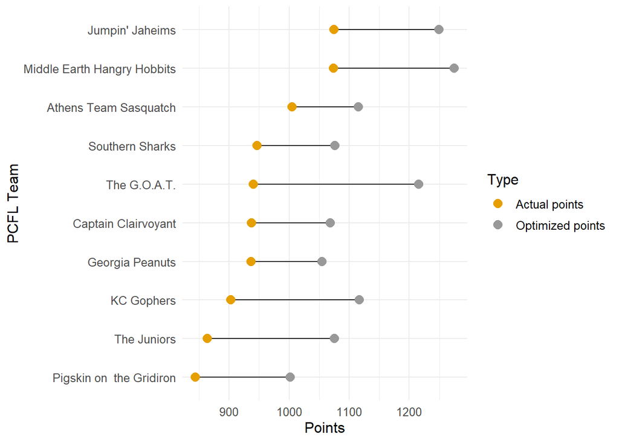

Still Scott and Evan at the top for both actual and optimized points, but both have left a lot on the table. Jacob’s gap is particularly notable as well.

### Best additions

There were 20 players added last week. Which was the **best new addition**?

| PCFL Team | Player | NFL Team | Position | Points |
| --- | --- | --- | --- | --- |
| Georgia Peanuts | Justin Fields | CHI | QB | 42.72 |
| The Juniors | Kenyan Drake | BAL | RB | 23.90 |
| Athens Team Sasquatch | Geno Smith | SEA | QB | 20.80 |
| Jumpin’ Jaheims | Trevor Lawrence | JAC | QB | 16.70 |
| Pigskin on the Gridiron | Curtis Samuel | WAS | WR | 16.60 |
| Captain Clairvoyant | Joshua Palmer | LAC | WR | 14.60 |
| Athens Team Sasquatch | Aaron Rodgers | GBP | QB | 13.64 |
| Pigskin on the Gridiron | Ryan Succop | TBB | K | 11.00 |
| Captain Clairvoyant | Rondale Moore | ARI | WR | 10.90 |
| Captain Clairvoyant | Seahawks D/ST | SEA | DST | 10.00 |
| KC Gophers | Buccaneers D/ST | TBB | DST | 9.00 |
| Athens Team Sasquatch | Vikings D/ST | MIN | DST | 8.00 |
| The Juniors | Marcus Mariota | ATL | QB | 7.56 |
| KC Gophers | AJ Dillon | GBP | RB | 5.40 |
| Athens Team Sasquatch | Deon Jackson | IND | RB | 4.60 |
| Southern Sharks | Michael Pittman Jr. | IND | WR | 3.70 |
| KC Gophers | Caleb Huntley | ATL | RB | 3.40 |
| Georgia Peanuts | Chase Claypool | CHI | WR | 2.70 |
| Pigskin on the Gridiron | Evan Engram | JAC | TE | 1.30 |
| Pigskin on the Gridiron | Broncos D/ST | DEN | DST | 0.00 |

Shoula coulda woulda played Justin Fields this week, but these things are unpredictable. Is there a better redemption story this season that Geno Smith and the Seahawks?

### Best team performances

Here’s a list of the **top five scoring performances** so far this season.

| PCFL Team | Week | Score | Result |
| --- | --- | --- | --- |
| Athens Team Sasquatch | 8 | 153.85 | W |
| Southern Sharks | 9 | 151.24 | W |
| Southern Sharks | 8 | 150.26 | L |
| Middle Earth Hangry Hobbits | 1 | 148.06 | W |
| Georgia Peanuts | 2 | 147.22 | W |

Sarah has two spots in the top five. She also only has two wins (and seven losses). Again, not sure what that means.

## Looking ahead

### League standings

[output not shown]

Evan remains our leader this week with his win, but both Scott and Robbie aren’t far behind. There’s a bunch of fighting for that last playoff spot.

### If the season ended today…

Here’s where this starts to get real, y’all. I’ve been thinking through both ESPN’s rankings and our point system as we go. My inclination is that playoffs would be decided based on the latter–the “team points” column-as I see that as being a fairer judge of team performance than just wins and losses. I’d keep the division winner/wildcard designations, though

Here’s what this would look like right now: * Division winners: Evan (14 points, Grits), and Scott (13 points, Hot Dish). * Wild cards: Robbbie (12 points) and Jacob (8 points and a points scored tie breaker)

The ESPN version would still be Evan and Scott as division winners, but the wildcards would be Robbie and Erin/Trav based on wins.

****If you have concerns about this system, let me know ASAP****

### Next week’s matchups

| Team 1 | Team 2 |
| --- | --- |
| Athens Team Sasquatch (Avg. last 3: 117.3) | Georgia Peanuts (Avg. last 3: 108.76) |
| Captain Clairvoyant (Avg. last 3: 101.49) | Pigskin on the Gridiron (Avg. last 3: 97.41) |
| Jumpin’ Jaheims (Avg. last 3: 113.45) | The G.O.A.T. (Avg. last 3: 95.39) |
| KC Gophers (Avg. last 3: 87.59) | Southern Sharks (Avg. last 3: 129.54) |
| Middle Earth Hangry Hobbits (Avg. last 3: 108.5) | The Juniors (Avg. last 3: 99.05) |

A good mix of games next week. As things start to get serious for the playoffs, we’ll see if Sarah can keep her hot streak going against Crissy. Richard had a VERY tough week last week, but he’ll try to take a bit out of Brian’s playoff dreams. Evan and Jacob face off in the Covenant youth bowl. There may be snow for the Minnesotan matchup of Scott and Erin/Trav. Lastly, I’ll try to stay alive for the playoffs against Robbie.

Good luck, y’all! (And check your byes!)